# PCT analysis

C.C.

2019年7月15日

## 前言

這一份資料根據e-mail的說明與補充 :

- Factor(六項)：
  1. Time
  2. Power
  3. Force
  4. Tail Length
  5. EFO Current
  6. Temp
- 檢測數據
  1. P/N pad Ball Shear(推力)
  2. P/N pad Ball Size(X、Y方向)
  3. P/N pad Ball thickness(Z方向)
- outlier
  1. 第01片 第5區塊 Ball-Size N(X) 第02顆 原數值是0.7，先暫定72
  2. 第05片 第5區塊 Ball-Size P(X) 第10顆 原數值是40，先暫定70
  3. 第17片 第5區塊 Ball-Size P(Y) 第08顆 原數值是752，先暫定73

## 資料表

|  | No. | Item | Time | Power | Force | Tail Length | EFO Current | Temp | Ball-area | Ball-Version | Ball-Shear | Ball-Size(X) | Ball-Size(Y) | Ball-Size(Z) |
| --- | --- | --- | --- | --- | --- | --- | --- | --- | --- | --- | --- | --- | --- | --- |
| 1 | 1 | 1 | 30 | 60 | 40 | 250 | 35 | 160 | 5 | P | 47.38 | 72 | 74 | 12 |
| 2 | 2 | 1 | 30 | 60 | 40 | 250 | 35 | 160 | 5 | P | 52.4 | 70 | 69 | 13 |
| 3 | 3 | 1 | 30 | 60 | 40 | 250 | 35 | 160 | 5 | P | 51.56 | 70 | 71 | 12 |
| 4 | 4 | 1 | 30 | 60 | 40 | 250 | 35 | 160 | 5 | P | 49.36 | 68 | 69 | 13 |
| 5 | 5 | 1 | 30 | 60 | 40 | 250 | 35 | 160 | 5 | P | 48.72 | 72 | 71 | 12 |
| 6 | 6 | 1 | 30 | 60 | 40 | 250 | 35 | 160 | 5 | P | 54.09 | 71 | 76 | 13 |
| 7 | 7 | 1 | 30 | 60 | 40 | 250 | 35 | 160 | 5 | P | 46.56 | 72 | 70 | 14 |
| 8 | 8 | 1 | 30 | 60 | 40 | 250 | 35 | 160 | 5 | P | 49.86 | 70 | 72 | 12 |
| 9 | 9 | 1 | 30 | 60 | 40 | 250 | 35 | 160 | 5 | P | 47.69 | 68 | 70 | 13 |
| 10 | 10 | 1 | 30 | 60 | 40 | 250 | 35 | 160 | 5 | P | 45.83 | 70 | 74 | 13 |

[output cut: 1070 more lines]

## 資料描述(factor)

```
##
##  DESCRIPTIVES
##
##  Descriptives
##  ──────────────────────────────────────────────────────────────────────────────────────────────────────────
##         Item    Time    Power    Force    Tail Length    EFO Current    Temp    Ball-area    Ball-Version
##  ──────────────────────────────────────────────────────────────────────────────────────────────────────────
##    N    1080    1080     1080     1080           1080           1080    1080         1080            1080
##  ──────────────────────────────────────────────────────────────────────────────────────────────────────────
##
##
##  FREQUENCIES
##
##  Frequencies of Item
##  ──────────────────────────────────────────────────
##    Levels    Counts    % of Total    Cumulative %
##  ──────────────────────────────────────────────────
##    1             60           5.6             5.6
##    10            60           5.6            11.1
##    11            60           5.6            16.7
##    12            60           5.6            22.2
##    13            60           5.6            27.8
##    14            60           5.6            33.3
##    15            60           5.6            38.9
##    16            60           5.6            44.4
##    17            60           5.6            50.0
##    18            60           5.6            55.6
##    2             60           5.6            61.1
##    3             60           5.6            66.7
##    4             60           5.6            72.2
##    5             60           5.6            77.8
##    6             60           5.6            83.3
##    7             60           5.6            88.9
##    8             60           5.6            94.4
##    9             60           5.6           100.0
##  ──────────────────────────────────────────────────
##
##
##  Frequencies of Time
##  ──────────────────────────────────────────────────
```

[output cut: 60 more lines]

```
##    Levels    Counts    % of Total    Cumulative %
##  ──────────────────────────────────────────────────
##    5            360          33.3            33.3
##    15           360          33.3            66.7
##    25           360          33.3           100.0
##  ──────────────────────────────────────────────────
##
##
##  Frequencies of Ball-Version
##  ──────────────────────────────────────────────────
##    Levels    Counts    % of Total    Cumulative %
##  ──────────────────────────────────────────────────
##    N            540          50.0            50.0
##    P            540          50.0           100.0
##  ──────────────────────────────────────────────────
```

## 資料描述(Response)

```
##
##  DESCRIPTIVES
##
##  Descriptives
##  ────────────────────────────────────────────────────────────────────────────────────
##                          Ball-Shear    Ball-Size(X)    Ball-Size(Y)    Ball-Size(Z)
##  ────────────────────────────────────────────────────────────────────────────────────
##    N                           1080            1080            1080            1080
##    Mean                        48.3            72.1            75.3            12.7
##    Median                      48.8            72.0            75.0            13.0
##    Standard deviation          4.43            2.35            4.56            1.43
##    Variance                    19.7            5.51            20.8            2.05
##    Range                       30.1            22.0            33.0            10.0
##    Minimum                     32.3            60.0            68.0            7.00
##    Maximum                     62.4            82.0             101            17.0
##  ────────────────────────────────────────────────────────────────────────────────────
```

## 第一部份:探索式分析

1. 先檢驗不同Time因子的 P版有無差異

```
##
##  ONE-WAY ANOVA (NON-PARAMETRIC)
##
##  Kruskal-Wallis
##  ────────────────────────────────────────
##                    χ2       df    p
##  ────────────────────────────────────────
##    Ball-Shear      0.605     2    0.739
##    Ball-Size(X)    4.801     2    0.091
##    Ball-Size(Y)    2.374     2    0.305
##    Ball-Size(Z)    8.467     2    0.015
##  ────────────────────────────────────────
```

2. 先檢驗不同Time因子的 N版有無差異

```
##
##  ONE-WAY ANOVA (NON-PARAMETRIC)
##
##  Kruskal-Wallis
##  ─────────────────────────────────────────
##                    χ2        df    p
##  ─────────────────────────────────────────
##    Ball-Shear       0.543     2    0.762
##    Ball-Size(X)     2.968     2    0.227
##    Ball-Size(Y)     9.878     2    0.007
##    Ball-Size(Z)    12.302     2    0.002
##  ─────────────────────────────────────────
```

3. 先檢驗不同 Power 因子的 P版有無差異

```
##
##  ONE-WAY ANOVA (NON-PARAMETRIC)
##
##  Kruskal-Wallis
##  ────────────────────────────────────────
##                    χ2      df    p
##  ────────────────────────────────────────
##    Ball-Shear      18.6     2    < .001
##    Ball-Size(X)    59.8     2    < .001
##    Ball-Size(Y)    68.4     2    < .001
##    Ball-Size(Z)    33.1     2    < .001
##  ────────────────────────────────────────
```

4. 先檢驗不同Power因子的 N版有無差異

```
##
##  ONE-WAY ANOVA (NON-PARAMETRIC)
##
##  Kruskal-Wallis
##  ────────────────────────────────────────
##                    χ2      df    p
##  ────────────────────────────────────────
##    Ball-Shear      10.3     2     0.006
##    Ball-Size(X)    62.2     2    < .001
##    Ball-Size(Y)    78.4     2    < .001
##    Ball-Size(Z)    41.9     2    < .001
##  ────────────────────────────────────────
```

5. 先檢驗不同Force因子的 P版有無差異

```
##
##  ONE-WAY ANOVA (NON-PARAMETRIC)
##
##  Kruskal-Wallis
##  ─────────────────────────────────────────
##                    χ2       df    p
##  ─────────────────────────────────────────
##    Ball-Shear      19.58     2    < .001
##    Ball-Size(X)    33.01     2    < .001
##    Ball-Size(Y)    30.26     2    < .001
##    Ball-Size(Z)     2.25     2     0.324
##  ─────────────────────────────────────────
```

6. 先檢驗不同 Force 因子的 N版有無差異

```
##
##  ONE-WAY ANOVA (NON-PARAMETRIC)
##
##  Kruskal-Wallis
##  ──────────────────────────────────────────
##                    χ2        df    p
##  ──────────────────────────────────────────
##    Ball-Shear      32.647     2    < .001
##    Ball-Size(X)    21.951     2    < .001
##    Ball-Size(Y)    41.507     2    < .001
##    Ball-Size(Z)     0.120     2     0.942
##  ──────────────────────────────────────────
```

7. 先檢驗不同Tail Length因子的 P版有無差異

```
##
##  ONE-WAY ANOVA (NON-PARAMETRIC)
##
##  Kruskal-Wallis
##  ─────────────────────────────────────────
##                    χ2       df    p
##  ─────────────────────────────────────────
##    Ball-Shear      41.58     2    < .001
##    Ball-Size(X)     5.63     2     0.060
##    Ball-Size(Y)     6.56     2     0.038
##    Ball-Size(Z)     9.31     2     0.010
##  ─────────────────────────────────────────
```

8. 先檢驗不同Tail Length因子的 N版有無差異

```
##
##  ONE-WAY ANOVA (NON-PARAMETRIC)
##
##  Kruskal-Wallis
##  ─────────────────────────────────────────
##                    χ2       df    p
##  ─────────────────────────────────────────
##    Ball-Shear      31.64     2    < .001
##    Ball-Size(X)     3.84     2     0.147
##    Ball-Size(Y)     6.07     2     0.048
##    Ball-Size(Z)    14.38     2    < .001
##  ─────────────────────────────────────────
```

9. 先檢驗不同EFO Current因子的 P版有無差異

```
##
##  ONE-WAY ANOVA (NON-PARAMETRIC)
##
##  Kruskal-Wallis
##  ─────────────────────────────────────────
##                    χ2       df    p
##  ─────────────────────────────────────────
##    Ball-Shear      71.83     2    < .001
##    Ball-Size(X)    12.78     2     0.002
##    Ball-Size(Y)     1.25     2     0.535
##    Ball-Size(Z)    78.22     2    < .001
##  ─────────────────────────────────────────
```

10. 先檢驗不同EFO Current因子的 N版有無差異

```
##
##  ONE-WAY ANOVA (NON-PARAMETRIC)
##
##  Kruskal-Wallis
##  ──────────────────────────────────────────
##                    χ2        df    p
##  ──────────────────────────────────────────
##    Ball-Shear      70.996     2    < .001
##    Ball-Size(X)     8.810     2     0.012
##    Ball-Size(Y)     0.824     2     0.662
##    Ball-Size(Z)    75.093     2    < .001
##  ──────────────────────────────────────────
```

11. 先檢驗不同 Temp 因子的 P版有無差異

```
##
##  ONE-WAY ANOVA (NON-PARAMETRIC)
##
##  Kruskal-Wallis
##  ──────────────────────────────────────────
##                    χ2        df    p
##  ──────────────────────────────────────────
##    Ball-Shear       0.729     2     0.695
##    Ball-Size(X)     7.739     2     0.021
##    Ball-Size(Y)    25.338     2    < .001
##    Ball-Size(Z)    53.917     2    < .001
##  ──────────────────────────────────────────
```

12. 先檢驗不同 Temp 因子的 N版有無差異

```
##
##  ONE-WAY ANOVA (NON-PARAMETRIC)
##
##  Kruskal-Wallis
##  ─────────────────────────────────────────
##                    χ2       df    p
##  ─────────────────────────────────────────
##    Ball-Shear       2.89     2     0.236
##    Ball-Size(X)    21.42     2    < .001
##    Ball-Size(Y)    16.61     2    < .001
##    Ball-Size(Z)    56.38     2    < .001
##  ─────────────────────────────────────────
```

## 第一部份小結

- 不同因子(Factor)會使 P/N 板子在檢驗值(Response)有不同的中位數，代表無法無視因子(Factor)的影響力
- 第二部份的分析會先檢查在同樣因子(Factor)下的檢驗值(Response)有無差異
  1. 如果無差異，會將其中6片相同因子(Factor)的數據整合後進行後續檢驗
  2. 如果有差異，代表製程本身的誤差波動是無法忽視的，即使P/N 板子檢定出有差異，也有可能只是製程本身的誤差
  3. 如果有差異，表示因子(Factor)是否真的會影響檢驗值(Response)，也是值得懷疑的

## 第二部份:驗證同因子製程誤差波動

(1)同製程因子的六片版互相對照，版子(P)編號(2,5,8,11,14,17)

```
##
##  ONE-WAY ANOVA (NON-PARAMETRIC)
##
##  Kruskal-Wallis
##  ────────────────────────────────────────
##                    χ2      df    p
##  ────────────────────────────────────────
##    Ball-Shear      13.7     5     0.017
##    Ball-Size(X)    80.0     5    < .001
##    Ball-Size(Y)    54.0     5    < .001
##    Ball-Size(Z)    32.5     5    < .001
##  ────────────────────────────────────────
```

(2)同製程因子的六片版互相對照，版子(N)編號(2,5,8,11,14,17)

```
##
##  ONE-WAY ANOVA (NON-PARAMETRIC)
##
##  Kruskal-Wallis
##  ────────────────────────────────────────
##                    χ2      df    p
##  ────────────────────────────────────────
##    Ball-Shear      13.3     5     0.021
##    Ball-Size(X)    85.8     5    < .001
##    Ball-Size(Y)    42.7     5    < .001
##    Ball-Size(Z)    57.1     5    < .001
##  ────────────────────────────────────────
```

(3)同製程因子的六片版分兩組比較，版子(P)編號(2,5,8),(11,14,17)

```
##
##  ONE-WAY ANOVA (NON-PARAMETRIC)
##
##  Kruskal-Wallis
##  ─────────────────────────────────────────
##                    χ2        df    p
##  ─────────────────────────────────────────
##    Ball-Shear      0.0384     1    0.845
##    Ball-Size(X)    0.0283     1    0.866
##    Ball-Size(Y)    6.2191     1    0.013
##    Ball-Size(Z)    0.8564     1    0.355
##  ─────────────────────────────────────────
```

(4)同製程因子的六片版分兩組比較，版子(N)編號(2,5,8),(11,14,17)

```
##
##  ONE-WAY ANOVA (NON-PARAMETRIC)
##
##  Kruskal-Wallis
##  ──────────────────────────────────────────
##                    χ2         df    p
##  ──────────────────────────────────────────
##    Ball-Shear        0.464     1    0.496
##    Ball-Size(X)    2.17e-4     1    0.988
##    Ball-Size(Y)      2.863     1    0.091
##    Ball-Size(Z)      0.688     1    0.407
##  ──────────────────────────────────────────
```

(5)同製程因子的六片版分 P/N 兩組比較，編號(2,5,8,11,14,17)

```
##
##  INDEPENDENT SAMPLES T-TEST
##
##  Independent Samples T-Test
##  ────────────────────────────────────────────────────────────────
##                                      statistic    df     p
##  ────────────────────────────────────────────────────────────────
##    Ball-Shear      Student's t           0.274    358     0.784
##                    Mann-Whitney U        15806            0.690
##
##    Ball-Size(X)    Student's t           3.175    358     0.002
##                    Mann-Whitney U        12735           < .001
##
##    Ball-Size(Y)    Student's t           5.613    358    < .001
##                    Mann-Whitney U        10930           < .001
##
##    Ball-Size(Z)    Student's t          -3.390    358    < .001
##                    Mann-Whitney U        13745            0.007
##  ────────────────────────────────────────────────────────────────
```

```
##
##  DESCRIPTIVES
##
##  Descriptives
##  ─────────────────────────────────────────────────────────────────────────────────────────────────────
##                           Ball-Version    Ball-Shear    Ball-Size(X)    Ball-Size(Y)    Ball-Size(Z)
##  ─────────────────────────────────────────────────────────────────────────────────────────────────────
##    N                      N                      180             180             180             180
##                           P                      180             180             180             180
##    Missing                N                        0               0               0               0
##                           P                        0               0               0               0
##    Mean                   N                     49.0            72.3            75.5            12.8
##                           P                     48.9            71.6            74.0            13.2
##    Median                 N                     49.3            72.0            76.0            13.0
##                           P                     49.1            72.0            74.0            13.0
##    Standard deviation     N                     3.16            2.17            2.54            1.17
##                           P                     2.87            1.91            2.66            1.00
##    Variance               N                     10.0            4.71            6.45            1.37
##                           P                     8.23            3.63            7.08            1.00
##    Minimum                N                     39.6            60.0            69.0            7.00
##                           P                     41.3            68.0            68.0            10.0
##    Maximum                N                     56.1            82.0            81.0            16.0
##                           P                     56.3            78.0            81.0            17.0
##    Skewness               N                   -0.357          -0.308          -0.119           -1.31
##                           P                   -0.327           0.469          0.0747           0.134
##    Std. error skewness    N                    0.181           0.181           0.181           0.181
##                           P                    0.181           0.181           0.181           0.181
##    Kurtosis               N                   -0.179            6.80          -0.173            3.77
##                           P                   -0.189          0.0324          -0.274            2.32
##    Std. error kurtosis    N                    0.360           0.360           0.360           0.360
##                           P                    0.360           0.360           0.360           0.360
##  ─────────────────────────────────────────────────────────────────────────────────────────────────────
```

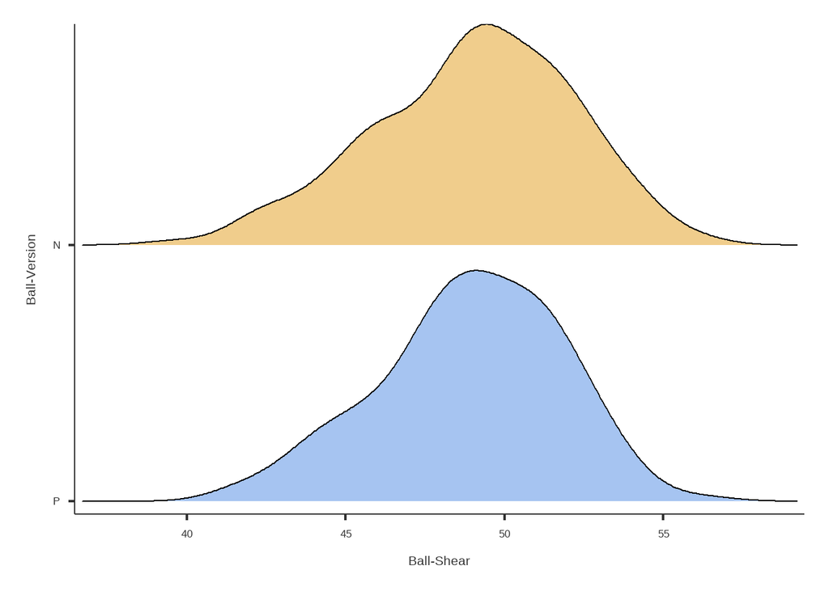

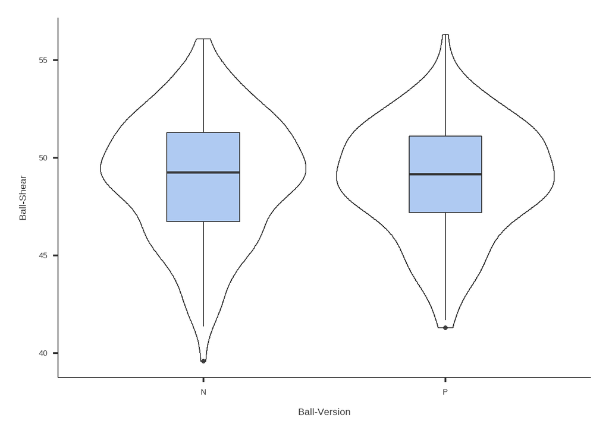

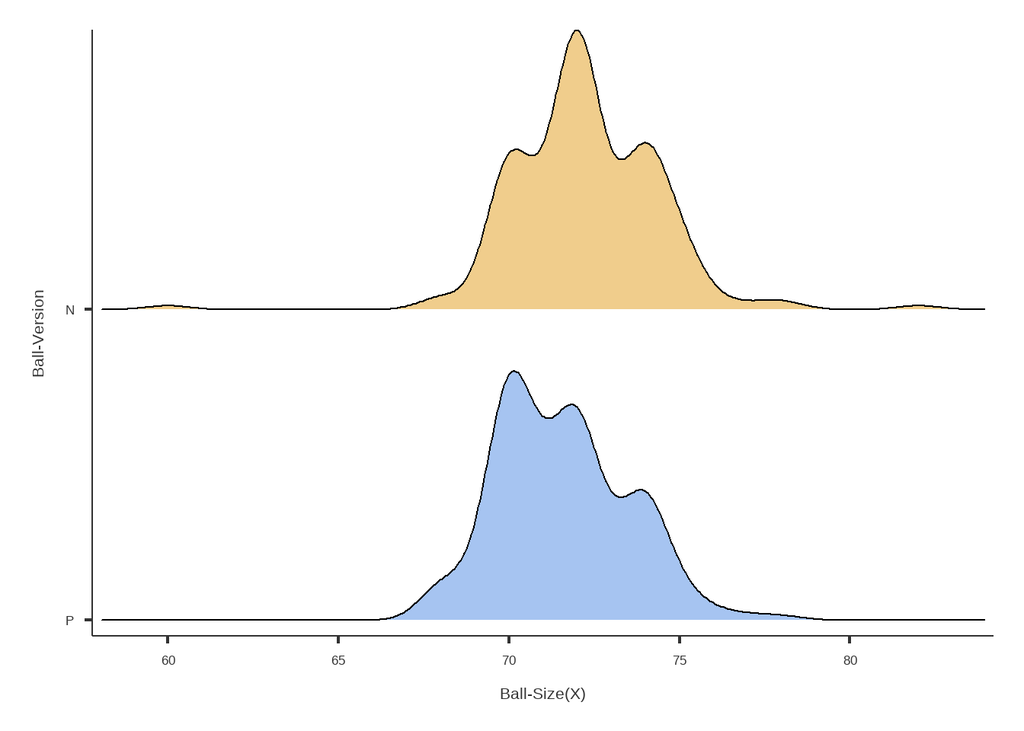

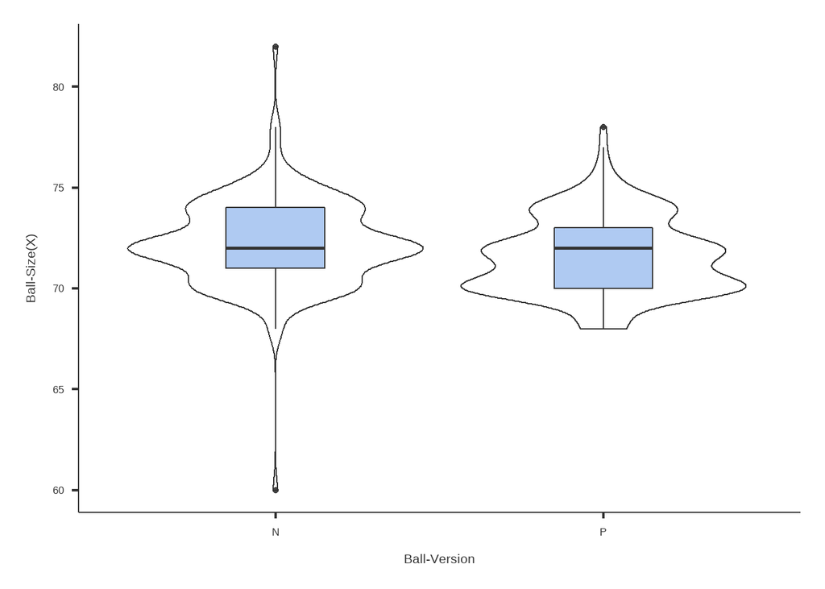

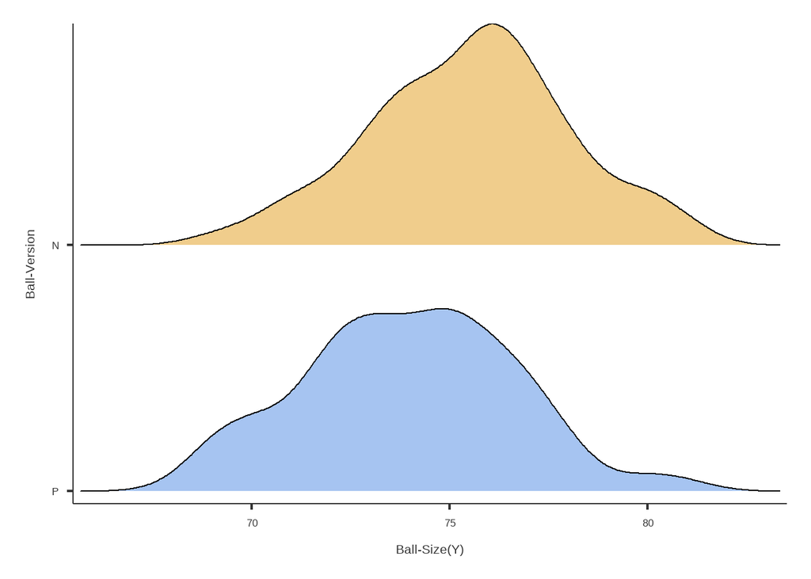

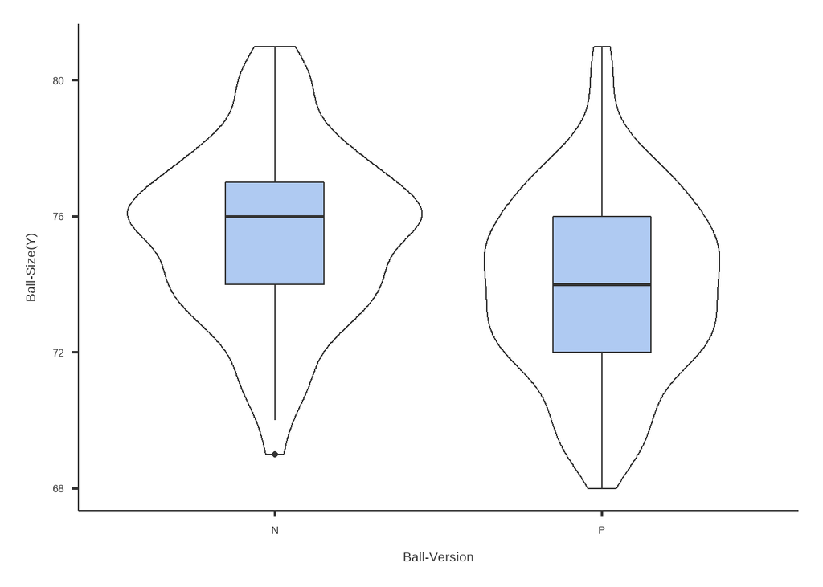

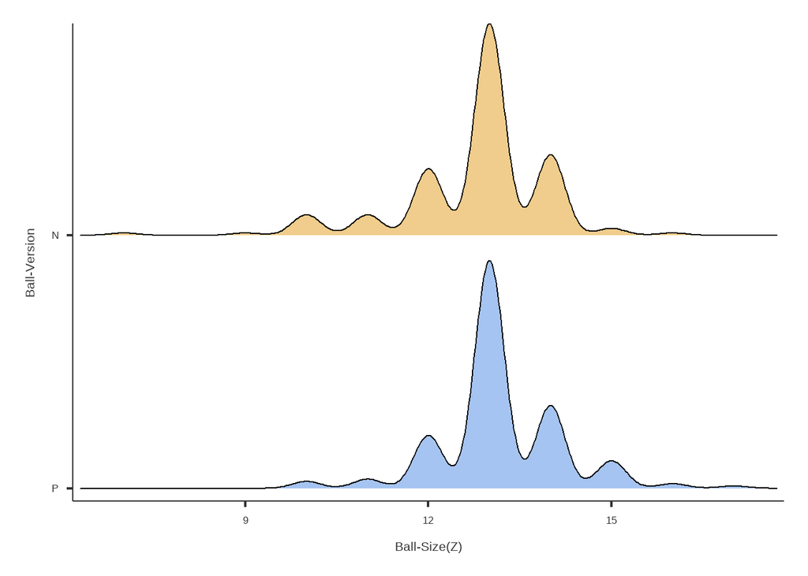

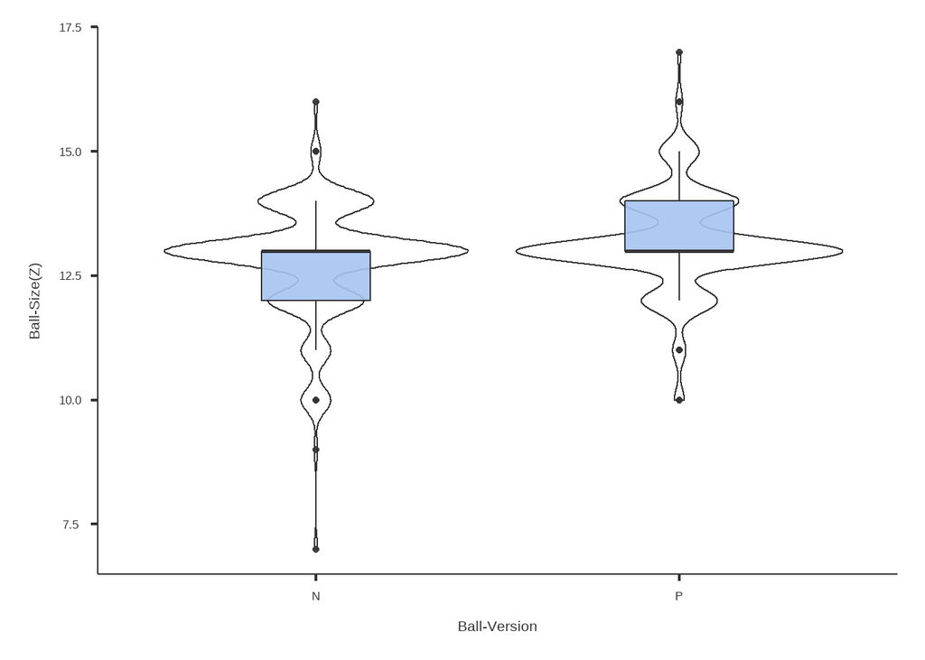

## 第二部份小結

- 第二部份的分析檢查出在同樣因子(Factor)下的檢驗值(Response)在Ball-Version P的Ball-Size(Y)兩組的中位數並不相同 ，其K-W test 的p值 = 0.013，但其他三項檢驗值(Response)，在增加樣本數後有顯著改善，這代表製程本身的波動可能是以片為單位，只要樣本數足夠的前提下不會影響到檢驗結果
- 在同樣因子(Factor) P/N Ball 在Ball-Size(X)、Ball-Size(Y)、Ball-Size(Z)這三項檢驗值(Response)有統計意義上的顯著差異
- 由統計值與圖表來看，這三項檢驗值(Response)它們的分布情況有些許差異，第三部份會嘗試運用這三項檢驗值(Response)將P/N Ball分群

## 結論

- 不同因子(Factor)會使 P/N 板子在檢驗值(Response)有不同的中位數，但也有可能是製程波動造成的，建議是增加樣本數後再進行檢定
- 製程本身的波動可能是以片為單位，只要樣本數足夠的前提下不會影響到檢驗結果
- 在同樣因子(Factor) N Ball在X、Y高於P Ball，在Z低於P Ball